# Analyze Collinsella

Yixuan Yang

# Set Up

```r
set.seed(2024)
library(tidyverse)
library(here)
library(rstatix)
library(phyloseq)
library(gt)
theme_set(theme_bw())

ps.rare <- readRDS(here('data','following_study','ps_rarefied.rds')) %>%
    filter_taxa(function(x) sum(x)>=50&sum(x>0)/length(x)>=0.1, prune = TRUE) # filter out taxa with prevalence lower than 10%
```

# Top Candidate

## Collinsella

We have found that `Collinsella` is the top candidate that influence dog’s microbiome. Here we investigate its existence. In this section, we will mainly test the association between the existence of `Collinsella` and the epilepsy status of the dogs.

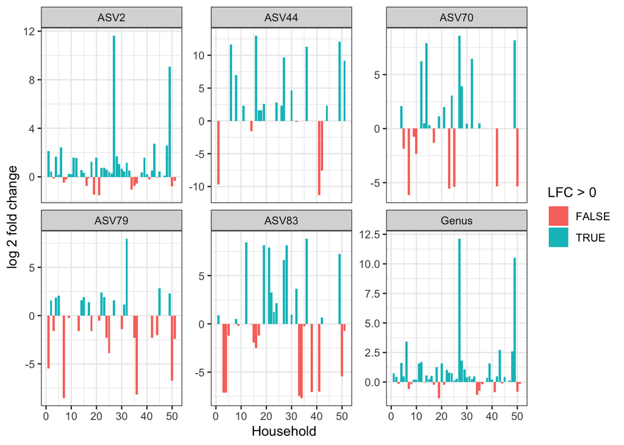

```r
ps.collinsella <- ps.rare %>%
    subset_taxa(Genus == 'Collinsella')

# add genus level collinsella count to otu table
collinsella.df <- otu_table(ps.collinsella) %>%
    cbind(Genus = rowSums(otu_table(ps.collinsella))) %>%
    cbind(data.frame(sample_data(ps.collinsella))) %>%
    pivot_longer(c(starts_with('ASV'), 'Genus'), names_to = 'ASV', values_to = 'Abundance')


lfc <- collinsella.df %>%
    group_by(Household, ASV) %>%
    summarise(LFC = log2(Abundance[Epileptic.or.Control == "Epileptic"] + 0.5) -
                  log2(Abundance[Epileptic.or.Control == "Control"] + 0.5),
              .groups = 'drop')

ggplot(lfc) +
    geom_bar(aes(x = as.numeric(Household), y = LFC, fill = (LFC > 0)), stat = 'identity') +
    facet_wrap(~ASV, scales = 'free_y') +
    labs(x = 'Household', y = 'log 2 fold change', fill = 'LFC > 0')
```

From the previous plot, we can see that some of the Collinsella ASVs are more abundant in the epileptic group than the control group. We can test this hypothesis using the pairwise sign test.

```r
collinsella.df %>%
    group_by(ASV) %>%
    arrange(Household) %>% # make sure data are paired
    pairwise_sign_test(Abundance ~ Epileptic.or.Control, ref.group = 'Epileptic', alternative = 'greater')
```

```
## # A tibble: 6 × 11
##   ASV   .y.   group1 group2    n1    n2 statistic    df     p p.adj p.adj.signif
## * <chr> <chr> <chr>  <chr>  <int> <int>     <dbl> <dbl> <dbl> <dbl> <chr>
## 1 ASV2  Abun… Epile… Contr…    49    49        34    49 0.005 0.005 **
## 2 ASV44 Abun… Epile… Contr…    49    49        15    20 0.021 0.021 *
## 3 ASV70 Abun… Epile… Contr…    49    49        14    23 0.202 0.202 ns
## 4 ASV79 Abun… Epile… Contr…    49    49        13    29 0.771 0.771 ns
## 5 ASV83 Abun… Epile… Contr…    49    49        15    30 0.572 0.572 ns
## 6 Genus Abun… Epile… Contr…    49    49        35    49 0.002 0.002 **
```

```r
ftable(xtabs(sign(Abundance) ~ Epileptic.or.Control + ASV, data = collinsella.df))
```

```
##                      ASV ASV2 ASV44 ASV70 ASV79 ASV83 Genus
## Epileptic.or.Control
## Control                    48     9    18    25    23    48
## Epileptic                  49    18    18    20    23    49
```

Previous studies shows that male dogs have a higher rate of having epilepsy. Here we investigate whether the existence of Collinsella is associated to sex.

```r
ftable(xtabs(sign(Abundance) ~ Sex  + Epileptic.or.Control + ASV, data = collinsella.df))
```

```
##                          ASV ASV2 ASV44 ASV70 ASV79 ASV83 Genus
## Sex Epileptic.or.Control
## F   Control                    32     6    13    20    16    32
##     Epileptic                  25     7    11    13    13    25
## M   Control                    16     3     5     5     7    16
##     Epileptic                  24    11     7     7    10    24
```

Chi-squared test between sex and health condition group for each ASV.

```r
collinsella.df %>%
    split(.$ASV) %>%
    lapply(function(df) summary(xtabs(sign(Abundance) ~ Sex  + Epileptic.or.Control, data = df)))
```

```
## $ASV2
## Call: xtabs(formula = sign(Abundance) ~ Sex + Epileptic.or.Control,
##     data = df)
## Number of cases in table: 97
## Number of factors: 2
## Test for independence of all factors:
##  Chisq = 2.4496, df = 1, p-value = 0.1176
##
## $ASV44
## Call: xtabs(formula = sign(Abundance) ~ Sex + Epileptic.or.Control,
##     data = df)
## Number of cases in table: 27
## Number of factors: 2
## Test for independence of all factors:
##  Chisq = 1.8544, df = 1, p-value = 0.1733
##  Chi-squared approximation may be incorrect
##
## $ASV70
## Call: xtabs(formula = sign(Abundance) ~ Sex + Epileptic.or.Control,
##     data = df)
## Number of cases in table: 36
## Number of factors: 2
## Test for independence of all factors:
##  Chisq = 0.5, df = 1, p-value = 0.4795
##
## $ASV79
## Call: xtabs(formula = sign(Abundance) ~ Sex + Epileptic.or.Control,
##     data = df)
## Number of cases in table: 45
## Number of factors: 2
## Test for independence of all factors:
##  Chisq = 1.2784, df = 1, p-value = 0.2582
##
## $ASV83
## Call: xtabs(formula = sign(Abundance) ~ Sex + Epileptic.or.Control,
##     data = df)
## Number of cases in table: 46
## Number of factors: 2
## Test for independence of all factors:
##  Chisq = 0.8398, df = 1, p-value = 0.3595
##
## $Genus
## Call: xtabs(formula = sign(Abundance) ~ Sex + Epileptic.or.Control,
##     data = df)
## Number of cases in table: 97
## Number of factors: 2
## Test for independence of all factors:
##  Chisq = 2.4496, df = 1, p-value = 0.1176
```

```r
ftable(xtabs(sign(Abundance) ~ Seizure.Freedom..Y.N.  + Pheno.Y.N + ASV, data = collinsella.df))
```

```
##                                 ASV ASV2 ASV44 ASV70 ASV79 ASV83 Genus
## Seizure.Freedom..Y.N. Pheno.Y.N
## No                    No              24     7     9     9    10    24
##                       Yes              8     3     2     4     4     8
## Yes                   No               5     2     1     1     1     5
##                       Yes             11     5     6     6     8    11
```

```r
collinsella.df %>%
    filter(Epileptic.or.Control == 'Epileptic') %>%
    split(.$ASV) %>%
    lapply(function(df) summary(xtabs(sign(Abundance) ~ Pheno.Y.N + Seizure.Freedom..Y.N., data = df)))
```

```
## $ASV2
## Call: xtabs(formula = sign(Abundance) ~ Pheno.Y.N + Seizure.Freedom..Y.N.,
##     data = df)
## Number of cases in table: 48
## Number of factors: 2
## Test for independence of all factors:
##  Chisq = 8.537, df = 1, p-value = 0.00348
##
## $ASV44
## Call: xtabs(formula = sign(Abundance) ~ Pheno.Y.N + Seizure.Freedom..Y.N.,
##     data = df)
## Number of cases in table: 17
## Number of factors: 2
## Test for independence of all factors:
##  Chisq = 2.8367, df = 1, p-value = 0.09213
##  Chi-squared approximation may be incorrect
##
## $ASV70
## Call: xtabs(formula = sign(Abundance) ~ Pheno.Y.N + Seizure.Freedom..Y.N.,
##     data = df)
## Number of cases in table: 18
## Number of factors: 2
## Test for independence of all factors:
##  Chisq = 7.901, df = 1, p-value = 0.00494
##  Chi-squared approximation may be incorrect
##
## $ASV79
## Call: xtabs(formula = sign(Abundance) ~ Pheno.Y.N + Seizure.Freedom..Y.N.,
##     data = df)
## Number of cases in table: 20
## Number of factors: 2
## Test for independence of all factors:
##  Chisq = 5.495, df = 1, p-value = 0.01908
##  Chi-squared approximation may be incorrect
##
## $ASV83
## Call: xtabs(formula = sign(Abundance) ~ Pheno.Y.N + Seizure.Freedom..Y.N.,
##     data = df)
## Number of cases in table: 23
## Number of factors: 2
## Test for independence of all factors:
##  Chisq = 7.987, df = 1, p-value = 0.00471
##  Chi-squared approximation may be incorrect
##
## $Genus
## Call: xtabs(formula = sign(Abundance) ~ Pheno.Y.N + Seizure.Freedom..Y.N.,
##     data = df)
## Number of cases in table: 48
## Number of factors: 2
## Test for independence of all factors:
##  Chisq = 8.537, df = 1, p-value = 0.00348
```

Does age associate to the abundance of Collinsella?

```r
collinsella.df %>%
    split(.$ASV) %>%
    lapply(function(df) MASS::glm.nb((Abundance + 1) ~ Age..months., data = df) %>% summary)
```

```
## $ASV2
##
## Call:
## MASS::glm.nb(formula = (Abundance + 1) ~ Age..months., data = df,
##     init.theta = 1.235180354, link = log)
##
## Coefficients:
##               Estimate Std. Error z value Pr(>|z|)
## (Intercept)   8.267549   0.214053   38.62   <2e-16 ***
## Age..months. -0.000204   0.002561   -0.08    0.937
## ---
## Signif. codes:  0 '***' 0.001 '**' 0.01 '*' 0.05 '.' 0.1 ' ' 1
##
## (Dispersion parameter for Negative Binomial(1.2352) family taken to be 1)
##
##     Null deviance: 110.96  on 97  degrees of freedom
## Residual deviance: 110.96  on 96  degrees of freedom
## AIC: 1816.9
##
## Number of Fisher Scoring iterations: 1
##
##
##               Theta:  1.235
##           Std. Err.:  0.160
##
##  2 x log-likelihood:  -1810.933
##
## $ASV44
##
## Call:
## MASS::glm.nb(formula = (Abundance + 1) ~ Age..months., data = df,
##     init.theta = 0.1695444493, link = log)
##
## Coefficients:
##              Estimate Std. Error z value Pr(>|z|)
## (Intercept)  4.102290   0.578033   7.097 1.28e-12 ***
## Age..months. 0.015678   0.006914   2.268   0.0234 *
## ---
## Signif. codes:  0 '***' 0.001 '**' 0.01 '*' 0.05 '.' 0.1 ' ' 1
##
```

[output cut: 106 more lines]

```
## Signif. codes:  0 '***' 0.001 '**' 0.01 '*' 0.05 '.' 0.1 ' ' 1
##
## (Dispersion parameter for Negative Binomial(1.4461) family taken to be 1)
##
##     Null deviance: 109.90  on 97  degrees of freedom
## Residual deviance: 109.65  on 96  degrees of freedom
## AIC: 1832.8
##
## Number of Fisher Scoring iterations: 1
##
##
##               Theta:  1.446
##           Std. Err.:  0.191
##
##  2 x log-likelihood:  -1826.842
```

# Callback to Pilot Study

In the pilot study, we have found Lactobacillus was associated with epilepsy. Here we investigate them like we did above.

## Lactobacillus

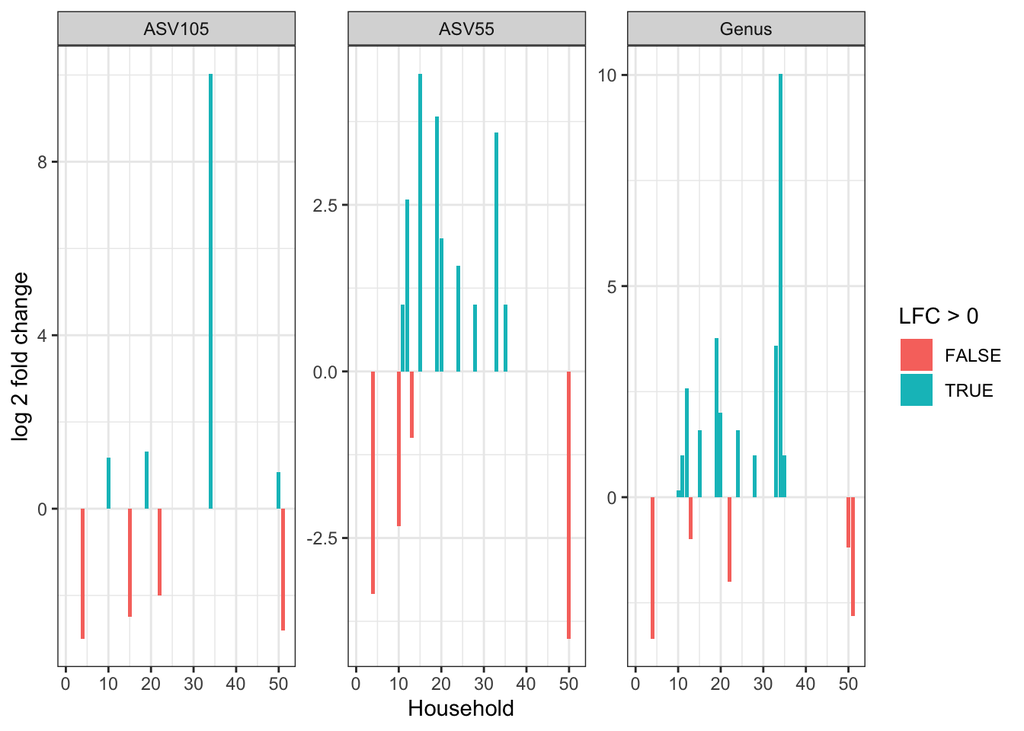

```r
ps.lactobacillus <- ps.rare %>%
    subset_taxa(Genus == 'Lactobacillus')

# add genus level lactobacillus count to otu table
lactobacillus.df <- otu_table(ps.lactobacillus) %>%
    cbind(Genus = rowSums(otu_table(ps.lactobacillus))) %>%
    cbind(data.frame(sample_data(ps.lactobacillus))) %>%
    pivot_longer(c(starts_with('ASV'), 'Genus'), names_to = 'ASV', values_to = 'Abundance')


lfc <- lactobacillus.df %>%
    group_by(Household, ASV) %>%
    summarise(LFC = log2(Abundance[Epileptic.or.Control == "Epileptic"] + 1) -
                  log2(Abundance[Epileptic.or.Control == "Control"] + 1),
              .groups = 'drop')

ggplot(lfc) +
    geom_bar(aes(x = as.numeric(Household), y = LFC, fill = (LFC > 0)), stat = 'identity') +
    facet_wrap(~ASV, scales = 'free_y') +
    labs(x = 'Household', y = 'log 2 fold change', fill = 'LFC > 0')
```

```r
lactobacillus.df %>%
    group_by(ASV) %>%
    arrange(Household) %>% # make sure data are paired
    pairwise_sign_test(Abundance ~ Epileptic.or.Control, ref.group = 'Epileptic', alternative = 'greater')
```

```
## # A tibble: 3 × 11
##   ASV   .y.   group1 group2    n1    n2 statistic    df     p p.adj p.adj.signif
## * <chr> <chr> <chr>  <chr>  <int> <int>     <dbl> <dbl> <dbl> <dbl> <chr>
## 1 ASV1… Abun… Epile… Contr…    49    49         4     8 0.637 0.637 ns
## 2 ASV55 Abun… Epile… Contr…    49    49         9    13 0.133 0.133 ns
## 3 Genus Abun… Epile… Contr…    49    49        11    16 0.105 0.105 ns
```

```r
# calculate prevalence
lactobacillus.df %>%
    group_by(ASV) %>%
    summarise(Prevalence = sum(Abundance > 0) / n())
```

```
## # A tibble: 3 × 2
##   ASV    Prevalence
##   <chr>       <dbl>
## 1 ASV105      0.122
## 2 ASV55       0.173
## 3 Genus       0.214
```

```r
ftable(xtabs(sign(Abundance) ~ Epileptic.or.Control + ASV, data = lactobacillus.df))
```

```
##                      ASV ASV105 ASV55 Genus
## Epileptic.or.Control
## Control                       7     6     8
## Epileptic                     5    11    13
```

Previous studies shows that male dogs have a higher rate of having epilepsy. Here we investigate whether the existence of lactobacillus is associated to sex.

```r
ftable(xtabs(sign(Abundance) ~ Sex + Epileptic.or.Control + ASV, data = lactobacillus.df))
```

```
##                          ASV ASV105 ASV55 Genus
## Sex Epileptic.or.Control
## F   Control                       5     4     5
##     Epileptic                     2     5     6
## M   Control                       2     2     3
##     Epileptic                     3     6     7
```

Chi-squared test between sex and health condition group for each ASV.

```r
lactobacillus.df %>%
    split(.$ASV) %>%
    lapply(function(df) summary(xtabs(sign(Abundance) ~ Sex  + Epileptic.or.Control, data = df)))
```

```
## $ASV105
## Call: xtabs(formula = sign(Abundance) ~ Sex + Epileptic.or.Control,
##     data = df)
## Number of cases in table: 12
## Number of factors: 2
## Test for independence of all factors:
##  Chisq = 1.1853, df = 1, p-value = 0.2763
##  Chi-squared approximation may be incorrect
##
## $ASV55
## Call: xtabs(formula = sign(Abundance) ~ Sex + Epileptic.or.Control,
##     data = df)
## Number of cases in table: 17
## Number of factors: 2
## Test for independence of all factors:
##  Chisq = 0.7012, df = 1, p-value = 0.4024
##  Chi-squared approximation may be incorrect
##
## $Genus
## Call: xtabs(formula = sign(Abundance) ~ Sex + Epileptic.or.Control,
##     data = df)
## Number of cases in table: 21
## Number of factors: 2
## Test for independence of all factors:
##  Chisq = 0.5305, df = 1, p-value = 0.4664
##  Chi-squared approximation may be incorrect
```

```r
ftable(xtabs(sign(Abundance) ~ Sex  + Pheno.Y.N + ASV, data = lactobacillus.df))
```

```
##               ASV ASV105 ASV55 Genus
## Sex Pheno.Y.N
## F   No                 5     6     7
##     Yes                2     3     4
## M   No                 4     7     9
##     Yes                1     1     1
```

```r
lactobacillus.df %>%
    filter(Epileptic.or.Control == 'Epileptic') %>%
    split(.$ASV) %>%
    lapply(function(df) summary(xtabs(sign(Abundance) ~ Pheno.Y.N, data = df)))
```

```
## $ASV105
## Number of cases in table: 5
## Number of factors: 1
##
## $ASV55
## Number of cases in table: 11
## Number of factors: 1
##
## $Genus
## Number of cases in table: 13
## Number of factors: 1
```

Does age associate to the abundance of lactobacillus?

```r
lactobacillus.df %>%
    split(.$ASV) %>%
    lapply(function(df) MASS::glm.nb((Abundance + 1) ~ Age..months., data = df) %>% summary)
```

```
## $ASV105
##
## Call:
## MASS::glm.nb(formula = (Abundance + 1) ~ Age..months., data = df,
##     init.theta = 0.2398608095, link = log)
##
## Coefficients:
##               Estimate Std. Error z value Pr(>|z|)
## (Intercept)  -0.018506   0.496372  -0.037     0.97
## Age..months.  0.042199   0.005894   7.160 8.09e-13 ***
## ---
## Signif. codes:  0 '***' 0.001 '**' 0.01 '*' 0.05 '.' 0.1 ' ' 1
##
## (Dispersion parameter for Negative Binomial(0.2399) family taken to be 1)
##
##     Null deviance: 151.82  on 97  degrees of freedom
## Residual deviance: 124.76  on 96  degrees of freedom
## AIC: 611.84
##
## Number of Fisher Scoring iterations: 1
##
##
##               Theta:  0.2399
##           Std. Err.:  0.0275
##
##  2 x log-likelihood:  -605.8430
##
## $ASV55
##
## Call:
## MASS::glm.nb(formula = (Abundance + 1) ~ Age..months., data = df,
##     init.theta = 0.240450765, link = log)
##
## Coefficients:
##              Estimate Std. Error z value Pr(>|z|)
## (Intercept)   0.89994    0.49110   1.832   0.0669 .
## Age..months.  0.03173    0.00585   5.424 5.81e-08 ***
## ---
## Signif. codes:  0 '***' 0.001 '**' 0.01 '*' 0.05 '.' 0.1 ' ' 1
##
```

[output cut: 25 more lines]

```
## Signif. codes:  0 '***' 0.001 '**' 0.01 '*' 0.05 '.' 0.1 ' ' 1
##
## (Dispersion parameter for Negative Binomial(0.2134) family taken to be 1)
##
##     Null deviance: 171.50  on 97  degrees of freedom
## Residual deviance: 129.79  on 96  degrees of freedom
## AIC: 688.08
##
## Number of Fisher Scoring iterations: 1
##
##
##               Theta:  0.2134
##           Std. Err.:  0.0241
##
##  2 x log-likelihood:  -682.0770
```

# Taxonomy Information

```r
prev <- ps.rare %>%
    psmelt() %>%
    filter(Genus %in% c('Collinsella', 'Lactobacillus')) %>%
    group_by(OTU, Genus) %>%
    summarise(Frequency = sum(Abundance > 0),
              Prevalence = sum(Abundance > 0) / n()) %>%
    arrange(Genus)
```

[output not shown]

```r
prev
```

```
## # A tibble: 7 × 4
## # Groups:   OTU [7]
##   OTU    Genus         Frequency Prevalence
##   <chr>  <chr>             <int>      <dbl>
## 1 ASV2   Collinsella          97      0.990
## 2 ASV44  Collinsella          27      0.276
## 3 ASV70  Collinsella          36      0.367
## 4 ASV79  Collinsella          45      0.459
## 5 ASV83  Collinsella          46      0.469
## 6 ASV105 Lactobacillus        12      0.122
## 7 ASV55  Lactobacillus        17      0.173
```

```r
tax_table(ps.rare)[prev$OTU, c('Genus','Species')]
```

```
## Taxonomy Table:     [7 taxa by 2 taxonomic ranks]:
##        Genus           Species
## ASV2   "Collinsella"   NA
## ASV44  "Collinsella"   "aerofaciens"
## ASV70  "Collinsella"   "tanakaei"
## ASV79  "Collinsella"   NA
## ASV83  "Collinsella"   "phocaeensis"
## ASV105 "Lactobacillus" NA
## ASV55  "Lactobacillus" NA
```

Some of the species were not identified. We can use blast to search against the nt/nr database.

```r
# extract sequence of these ASVs
refseq(ps.rare)[prev$OTU] %>% dada2:::pfasta(ids = prev$OTU)
```

```
## >ASV2
## TACGTAGGGGGCGAGCGTTATCCGGATTCATTGGGCGTAAAGCGCGCGTAGGCGGCCCGG…
## >ASV44
## TACGTAGGGGGCGAGCGTTATCCGGATTCATTGGGCGTAAAGCGCGCGTAGGCGGCCCGG…
## >ASV70
## TACGTAGGGGGCGAGCGTTATCCGGATTCATTGGGCGTAAAGCGCGCGTAGGCGGCCGCG…
## >ASV79
## TACGTAGGGGGCGAGCGTTATCCGGATTCATTGGGCGTAAAGCGCGCGTAGGCGGCCGCG…
## >ASV83
## TACGTAGGGGGCGAGCGTTATCCGGATTCATTGGGCGTAAAGCGCGCGTAGGCGGCCCGG…
## >ASV105
## TACGTAGGTGGCAAGCGTTGTCCGGATTTATTGGGCGTAAAGCGAGTGCAGGCGGTTCAA…
## >ASV55
## TACGTAGGTGGCAAGCGTTGTCCGGATTTATTGGGCGTAAAGCGAGCGCAGGCGGAAGAA…
```

Here’s the result:

[output not shown]

```r
df <- data.frame(sample_data(ps.rare))
df.sub <- df %>% filter(Seizure.Control..Satisfactory.Unsatisfactory. == 'S')
xtabs(~ Pheno.Y.N+Seizure.Freedom..Y.N., data = df.sub) %>% summary()
```

```
## Call: xtabs(formula = ~Pheno.Y.N + Seizure.Freedom..Y.N., data = df.sub)
## Number of cases in table: 35
## Number of factors: 2
## Test for independence of all factors:
##  Chisq = 10.151, df = 1, p-value = 0.001442
```